# kaggle_Kr_4th_05_1st_review

### 캐글 코리아 4차 대회

### 학습내용

- 상위 솔루션을 분석해 봅니다.(1st)
- 대회 링크 : https://www.kaggle.com/c/kakr-4th-competition/overview
- 참고 링크 : https://www.kaggle.com/code/bestend/kakr-4th-1st-place-solution (1st)

### 목차

01. 라이브러리 임포트 및 데이터 준비  
02. 데이터 탐색  
03. 모델링

### 01. 데이터 준비 및 라이브러리 임포트

목차로 이동하기

### 설치

- pip install [라이브러리명]

```python
import numpy as np # linear algebra
import pandas as pd # data processing, CSV file I/O (e.g. pd.read_csv)
import os
import numpy as np
import pandas as pd
import matplotlib.pyplot as plt
import seaborn as sns
import lightgbm as lgb
import pycaret

import os
for dirname, _, filenames in os.walk('/kaggle/input'):
    for filename in filenames:
        print(os.path.join(dirname, filename))

import warnings
warnings.filterwarnings('ignore')

from IPython.display import display

pd.options.display.max_rows = 10000
pd.options.display.max_columns = 1000
pd.options.display.max_colwidth = 1000
```

```python
print("lightgbm ver : ", lgb.__version__)
print("pycaret ver : ", pycaret.__version__)
```

```
lightgbm ver :  3.1.1
pycaret ver :  2.3.10
```

### 데이터 탐색

데이터 정보

```
age : 나이
workclass : 고용 형태
fnlwgt : 사람 대표성을 나타내는 가중치 (final weight의 약자)
education : 교육 수준 (최종 학력)
education_num : 교육 수준 수치
marital_status: 결혼 상태
occupation : 업종
relationship : 가족 관계
race : 인종
sex : 성별
capital_gain : 양도 소득
capital_loss : 양도 손실
hours_per_week : 주당 근무 시간
native_country : 국적
income : 수익 (예측해야 하는 값, target variable)
```

```python
dirname = "data/4th_kaggle"

train = pd.read_csv(os.path.join(dirname, 'train.csv'), index_col='id')
test = pd.read_csv(os.path.join(dirname, 'test.csv'), index_col='id')

train.shape, test.shape
```

```
((26049, 15), (6512, 14))
```

EDA 참고 링크

https://github.com/Aditya-Mankar/Census-Income-Prediction

### 02. 데이터 탐색

목차로 이동하기

```python
# 데이터 살펴보기
train.head()
```

| id | age | workclass | fnlwgt | education | education_num | marital_status | occupation | relationship | race | sex | capital_gain | capital_loss | hours_per_week | native_country | income |
| --- | --- | --- | --- | --- | --- | --- | --- | --- | --- | --- | --- | --- | --- | --- | --- |
| 0 | 40 | Private | 168538 | HS-grad | 9 | Married-civ-spouse | Sales | Husband | White | Male | 0 | 0 | 60 | United-States | >50K |
| 1 | 17 | Private | 101626 | 9th | 5 | Never-married | Machine-op-inspct | Own-child | White | Male | 0 | 0 | 20 | United-States | <=50K |
| 2 | 18 | Private | 353358 | Some-college | 10 | Never-married | Other-service | Own-child | White | Male | 0 | 0 | 16 | United-States | <=50K |
| 3 | 21 | Private | 151158 | Some-college | 10 | Never-married | Prof-specialty | Own-child | White | Female | 0 | 0 | 25 | United-States | <=50K |
| 4 | 24 | Private | 122234 | Some-college | 10 | Never-married | Adm-clerical | Not-in-family | Black | Female | 0 | 0 | 20 | ? | <=50K |

```python
# 데이터 구조
print('Rows: {} Columns: {}'.format(train.shape[0], train.shape[1]))
print('Rows: {} Columns: {}'.format(test.shape[0], test.shape[1]))
```

[output not shown]

```python
### 데이터 정보 확인
train.info(), test.info()
```

```
<class 'pandas.core.frame.DataFrame'>
Int64Index: 26049 entries, 0 to 26048
Data columns (total 15 columns):
 #   Column          Non-Null Count  Dtype
---  ------          --------------  -----
 0   age             26049 non-null  int64
 1   workclass       26049 non-null  object
 2   fnlwgt          26049 non-null  int64
 3   education       26049 non-null  object
 4   education_num   26049 non-null  int64
 5   marital_status  26049 non-null  object
 6   occupation      26049 non-null  object
 7   relationship    26049 non-null  object
 8   race            26049 non-null  object
 9   sex             26049 non-null  object
 10  capital_gain    26049 non-null  int64
 11  capital_loss    26049 non-null  int64
 12  hours_per_week  26049 non-null  int64
 13  native_country  26049 non-null  object
 14  income          26049 non-null  object
dtypes: int64(6), object(9)
memory usage: 3.2+ MB
<class 'pandas.core.frame.DataFrame'>
Int64Index: 6512 entries, 0 to 6511
Data columns (total 14 columns):
 #   Column          Non-Null Count  Dtype
---  ------          --------------  -----
 0   age             6512 non-null   int64
 1   workclass       6512 non-null   object
 2   fnlwgt          6512 non-null   int64
 3   education       6512 non-null   object
 4   education_num   6512 non-null   int64
 5   marital_status  6512 non-null   object
 6   occupation      6512 non-null   object
 7   relationship    6512 non-null   object
 8   race            6512 non-null   object
 9   sex             6512 non-null   object
 10  capital_gain    6512 non-null   int64
 11  capital_loss    6512 non-null   int64
 12  hours_per_week  6512 non-null   int64
 13  native_country  6512 non-null   object
dtypes: int64(6), object(8)
memory usage: 763.1+ KB
```

```
(None, None)
```

```python
### 통계적 요약
display(train.describe().T)
display(test.describe().T)
```

|  | count | mean | std | min | 25% | 50% | 75% | max |
| --- | --- | --- | --- | --- | --- | --- | --- | --- |
| age | 26049.0 | 38.569235 | 13.671489 | 17.0 | 28.0 | 37.0 | 48.0 | 90.0 |
| fnlwgt | 26049.0 | 190304.481708 | 105966.299073 | 13769.0 | 118108.0 | 178866.0 | 237735.0 | 1484705.0 |
| education_num | 26049.0 | 10.088372 | 2.567610 | 1.0 | 9.0 | 10.0 | 12.0 | 16.0 |
| capital_gain | 26049.0 | 1087.689700 | 7388.854690 | 0.0 | 0.0 | 0.0 | 0.0 | 99999.0 |
| capital_loss | 26049.0 | 87.732734 | 403.230205 | 0.0 | 0.0 | 0.0 | 0.0 | 4356.0 |
| hours_per_week | 26049.0 | 40.443126 | 12.361850 | 1.0 | 40.0 | 40.0 | 45.0 | 99.0 |

|  | count | mean | std | min | 25% | 50% | 75% | max |
| --- | --- | --- | --- | --- | --- | --- | --- | --- |
| age | 6512.0 | 38.631296 | 13.516418 | 17.0 | 28.00 | 37.0 | 48.00 | 90.0 |
| fnlwgt | 6512.0 | 187673.824939 | 103849.326430 | 12285.0 | 116504.25 | 176882.0 | 235850.75 | 1125613.0 |
| education_num | 6512.0 | 10.049908 | 2.593033 | 1.0 | 9.00 | 10.0 | 12.00 | 16.0 |
| capital_gain | 6512.0 | 1037.483876 | 7371.453668 | 0.0 | 0.00 | 0.0 | 0.00 | 99999.0 |
| capital_loss | 6512.0 | 85.588145 | 401.904741 | 0.0 | 0.00 | 0.0 | 0.00 | 4356.0 |
| hours_per_week | 6512.0 | 40.414773 | 12.290491 | 1.0 | 40.00 | 40.0 | 45.00 | 99.0 |

```python
# null 값이 존재하는지 확인
dat = (train.isnull().sum() / train.shape[0]) * 100
round(dat, 2).astype(str) + ' %'
```

```
age               0.0 %
workclass         0.0 %
fnlwgt            0.0 %
education         0.0 %
education_num     0.0 %
marital_status    0.0 %
occupation        0.0 %
relationship      0.0 %
race              0.0 %
sex               0.0 %
capital_gain      0.0 %
capital_loss      0.0 %
hours_per_week    0.0 %
native_country    0.0 %
income            0.0 %
dtype: object
```

```python
dat = (train.isin(['?']).sum() / train.shape[0])
round(dat, 2).astype(str) + ' %'
```

```
age                0.0 %
workclass         0.06 %
fnlwgt             0.0 %
education          0.0 %
education_num      0.0 %
marital_status     0.0 %
occupation        0.06 %
relationship       0.0 %
race               0.0 %
sex                0.0 %
capital_gain       0.0 %
capital_loss       0.0 %
hours_per_week     0.0 %
native_country    0.02 %
income             0.0 %
dtype: object
```

```python
dat = (test.isin(['?']).sum() / train.shape[0])
round(dat, 2).astype(str) + ' %'
```

```
age                0.0 %
workclass         0.01 %
fnlwgt             0.0 %
education          0.0 %
education_num      0.0 %
marital_status     0.0 %
occupation        0.01 %
relationship       0.0 %
race               0.0 %
sex                0.0 %
capital_gain       0.0 %
capital_loss       0.0 %
hours_per_week     0.0 %
native_country     0.0 %
dtype: object
```

```python
# 소득 비율
income = train['income'].value_counts(normalize=True)
round(income * 100, 2).astype('str') + ' %'
```

```
<=50K    75.8 %
>50K     24.2 %
Name: income, dtype: object
```

### 데이터 탐색 및 분석

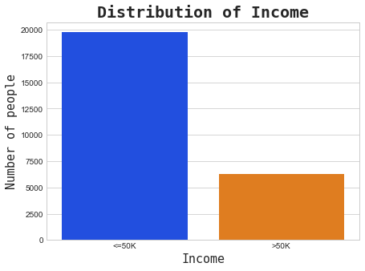

```python
# Creating a barplot for 'Income'
income = train['income'].value_counts()

plt.style.use('seaborn-whitegrid')
plt.figure(figsize=(7, 5))
sns.barplot(income.index, income.values, palette='bright')

plt.title('Distribution of Income',
          fontdict={
          'fontname': 'Monospace', 'fontsize': 20, 'fontweight': 'bold'})

plt.xlabel('Income', fontdict={'fontname': 'Monospace', 'fontsize': 15})
plt.ylabel('Number of people', fontdict={
           'fontname': 'Monospace', 'fontsize': 15})

plt.tick_params(labelsize=10)
plt.show()
```

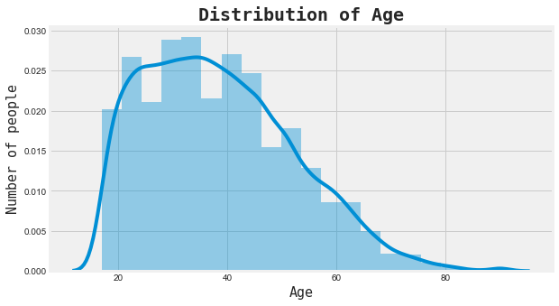

```python
# Creating a distribution plot for 'Age'
age = train['age'].value_counts()

plt.figure(figsize=(10, 5))
plt.style.use('fivethirtyeight')
sns.distplot(train['age'], bins=20)

plt.title('Distribution of Age', fontdict={
          'fontname': 'Monospace', 'fontsize': 20, 'fontweight': 'bold'})

plt.xlabel('Age', fontdict={'fontname': 'Monospace', 'fontsize': 15})
plt.ylabel('Number of people', fontdict={
           'fontname': 'Monospace', 'fontsize': 15})

plt.tick_params(labelsize=10)
plt.show()
```

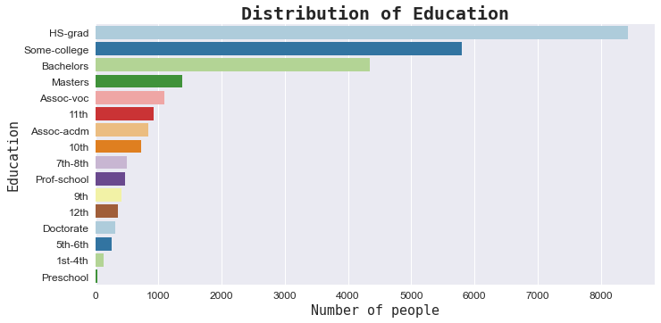

```python
# Creating a barplot for 'Education'
edu = train['education'].value_counts()

plt.style.use('seaborn')
plt.figure(figsize=(10, 5))
sns.barplot(edu.values, edu.index, palette='Paired')

plt.title('Distribution of Education', fontdict={
          'fontname': 'Monospace', 'fontsize': 20, 'fontweight': 'bold'})
plt.xlabel('Number of people', fontdict={
           'fontname': 'Monospace', 'fontsize': 15})
plt.ylabel('Education', fontdict={'fontname': 'Monospace',
                                  'fontsize': 15})
plt.tick_params(labelsize=12)
plt.show()
```

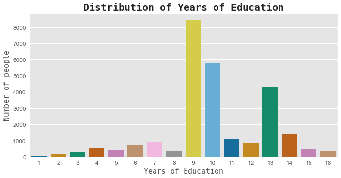

```python
# Creating a barplot for 'Years of Education'
edu_num = train['education_num'].value_counts()

plt.style.use('ggplot')
plt.figure(figsize=(10, 5))
sns.barplot(edu_num.index, edu_num.values, palette='colorblind')

plt.title('Distribution of Years of Education', fontdict={
          'fontname': 'Monospace', 'fontsize': 20, 'fontweight': 'bold'})
plt.xlabel('Years of Education', fontdict={
           'fontname': 'Monospace', 'fontsize': 15})
plt.ylabel('Number of people', fontdict={
           'fontname': 'Monospace', 'fontsize': 15})

plt.tick_params(labelsize=12)
plt.show()
```

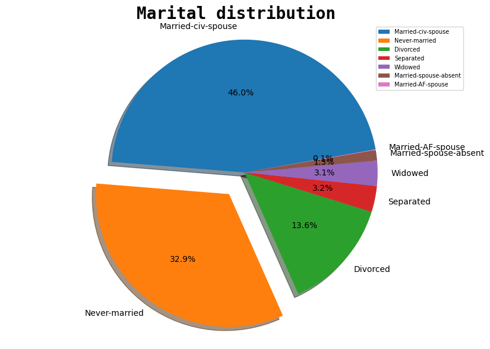

```python
# Creating a pie chart for 'Marital status'
marital = train['marital_status'].value_counts()

plt.style.use('default')
plt.figure(figsize=(10, 7))
plt.pie(marital.values,
        labels=marital.index, startangle=10,
        explode=(0, 0.20, 0, 0, 0, 0, 0), shadow=True, autopct='%1.1f%%')

plt.title('Marital distribution',
          fontdict={
          'fontname': 'Monospace', 'fontsize': 20, 'fontweight': 'bold'})

plt.legend()
plt.legend(prop={'size': 7})
plt.axis('equal')
plt.show()
```

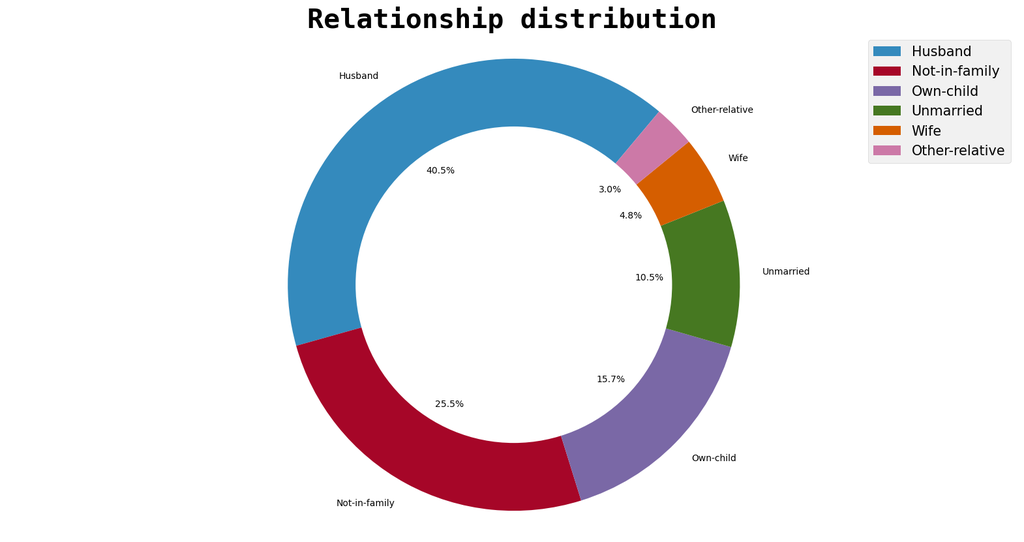

```python
# Creating a donut chart for 'Age'
relation = train['relationship'].value_counts()

plt.style.use('bmh')
plt.figure(figsize=(20, 10))
plt.pie(relation.values,
        labels=relation.index,
        startangle=50, autopct='%1.1f%%')

centre_circle = plt.Circle((0, 0), 0.7, fc='white')

fig = plt.gcf()
fig.gca().add_artist(centre_circle)
plt.title('Relationship distribution',
          fontdict={
          'fontname': 'Monospace', 'fontsize': 30, 'fontweight': 'bold'})
plt.axis('equal')
plt.legend(prop={'size': 15})
plt.show()
```

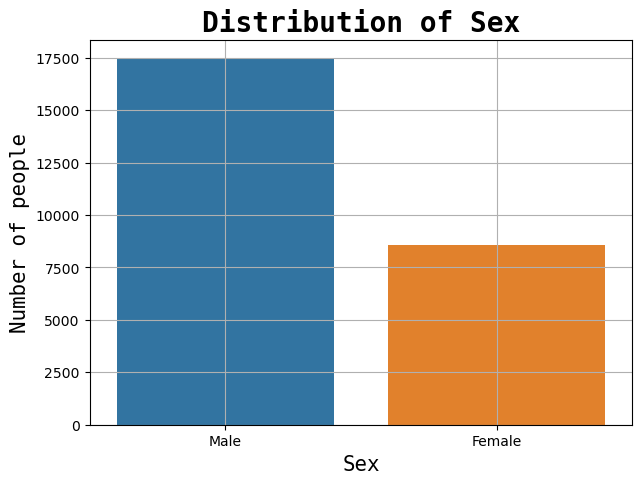

```python
# Creating a barplot for 'Sex'
sex = train['sex'].value_counts()

plt.style.use('default')
plt.figure(figsize=(7, 5))
sns.barplot(sex.index, sex.values)

plt.title('Distribution of Sex', fontdict={
          'fontname': 'Monospace', 'fontsize': 20, 'fontweight': 'bold'})
plt.xlabel('Sex', fontdict={'fontname': 'Monospace', 'fontsize': 15})
plt.ylabel('Number of people', fontdict={
           'fontname': 'Monospace', 'fontsize': 15})

plt.tick_params(labelsize=10)
plt.grid()
plt.show()
```

```python
# Creating a Treemap for 'Race'
import squarify
```

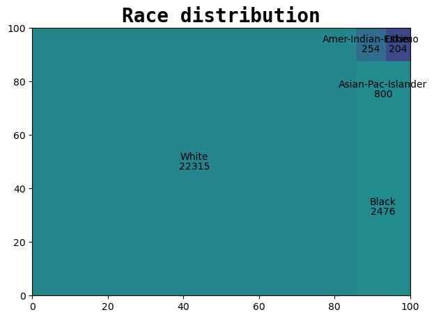

```python
race = train['race'].value_counts()

plt.style.use('default')
plt.figure(figsize=(7, 5))
squarify.plot(sizes=race.values, label=race.index, value=race.values)

plt.title('Race distribution', fontdict={
          'fontname': 'Monospace', 'fontsize': 20, 'fontweight': 'bold'})
plt.show()
```

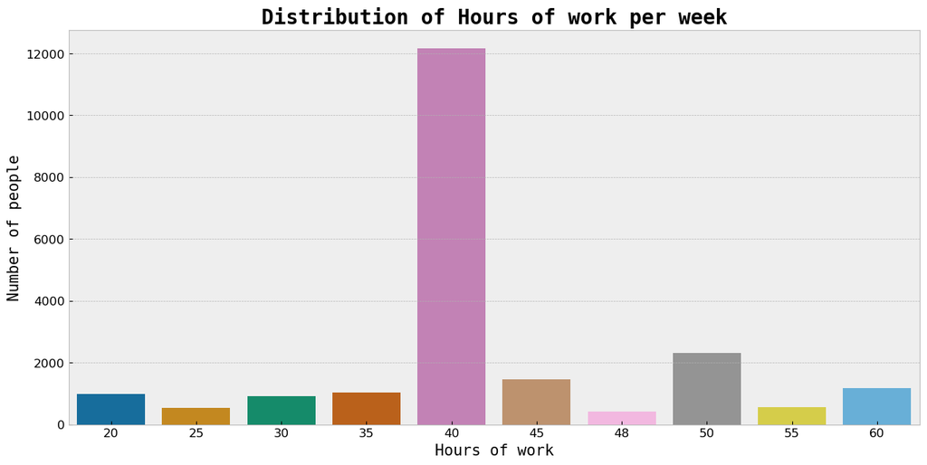

```python
# Creating a barplot for 'Hours per week'
hours = train['hours_per_week'].value_counts().head(10)

plt.style.use('bmh')
plt.figure(figsize=(15, 7))
sns.barplot(hours.index, hours.values, palette='colorblind')

plt.title('Distribution of Hours of work per week', fontdict={
          'fontname': 'Monospace', 'fontsize': 20, 'fontweight': 'bold'})
plt.xlabel('Hours of work', fontdict={'fontname': 'Monospace', 'fontsize': 15})
plt.ylabel('Number of people', fontdict={
           'fontname': 'Monospace', 'fontsize': 15})
plt.tick_params(labelsize=12)
plt.show()
```

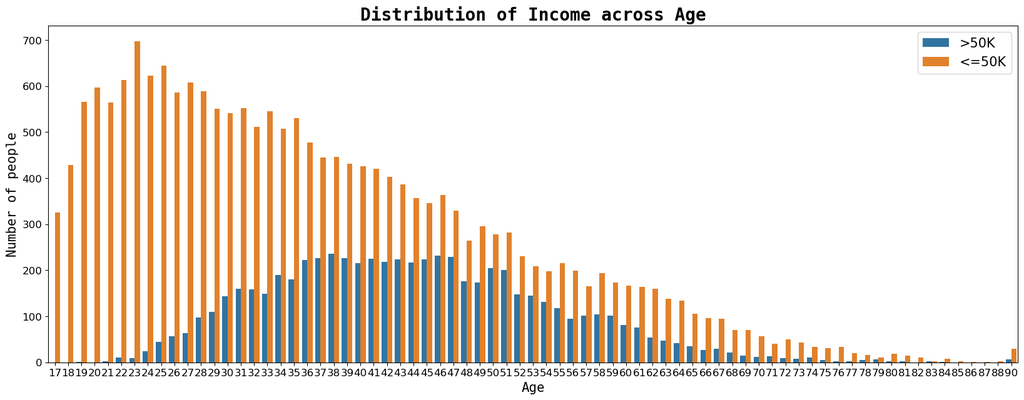

```python
# Creating a countplot of income across age
plt.style.use('default')
plt.figure(figsize=(20, 7))
sns.countplot(train['age'], hue=train['income'])

plt.title('Distribution of Income across Age', fontdict={
          'fontname': 'Monospace', 'fontsize': 20, 'fontweight': 'bold'})
plt.xlabel('Age', fontdict={'fontname': 'Monospace', 'fontsize': 15})
plt.ylabel('Number of people', fontdict={
           'fontname': 'Monospace', 'fontsize': 15})

plt.tick_params(labelsize=12)
plt.legend(loc=1, prop={'size': 15})
plt.show()
```

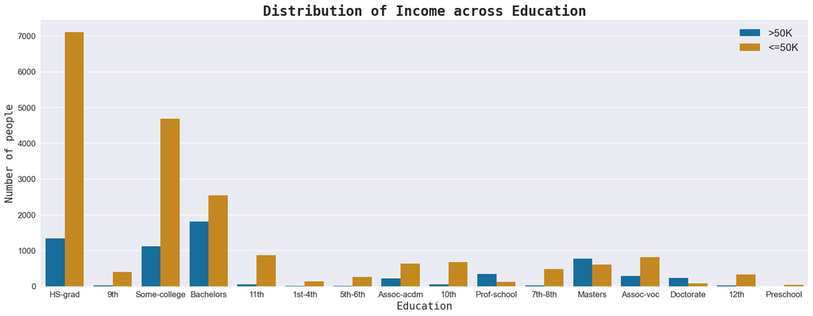

```python
# Creating a countplot of income across education
plt.style.use('seaborn')
plt.figure(figsize=(20, 7))
sns.countplot(train['education'],
              hue=train['income'],
              palette='colorblind')

plt.title('Distribution of Income across Education', fontdict={
          'fontname': 'Monospace', 'fontsize': 20, 'fontweight': 'bold'})
plt.xlabel('Education', fontdict={'fontname': 'Monospace', 'fontsize': 15})
plt.ylabel('Number of people', fontdict={
           'fontname': 'Monospace', 'fontsize': 15})

plt.tick_params(labelsize=12)
plt.legend(loc=1, prop={'size': 15})
plt.show()
```

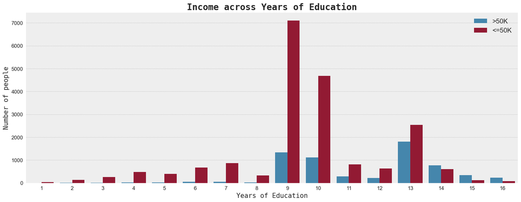

```python
# Creating a countplot of income across years of education
plt.style.use('bmh')
plt.figure(figsize=(20, 7))
sns.countplot(train['education_num'],
              hue=train['income'])

plt.title('Income across Years of Education', fontdict={
          'fontname': 'Monospace', 'fontsize': 20, 'fontweight': 'bold'})
plt.xlabel('Years of Education', fontdict={
           'fontname': 'Monospace', 'fontsize': 15})
plt.ylabel('Number of people', fontdict={
           'fontname': 'Monospace', 'fontsize': 15})
plt.tick_params(labelsize=12)
plt.legend(loc=1, prop={'size': 15})
plt.savefig('bi2.png')
plt.show()
```

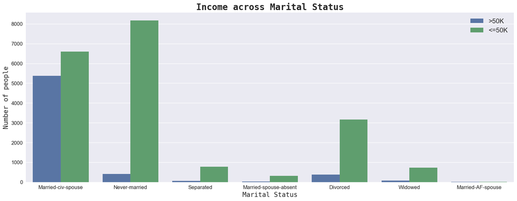

```python
# Creating a countplot of income across Marital Status
plt.style.use('seaborn')
plt.figure(figsize=(20, 7))
sns.countplot(train['marital_status'], hue=train['income'])

plt.title('Income across Marital Status', fontdict={
          'fontname': 'Monospace', 'fontsize': 20, 'fontweight': 'bold'})
plt.xlabel('Marital Status', fontdict={
           'fontname': 'Monospace', 'fontsize': 15})
plt.ylabel('Number of people', fontdict={
           'fontname': 'Monospace', 'fontsize': 15})

plt.tick_params(labelsize=12)
plt.legend(loc=1, prop={'size': 15})
plt.show()
```

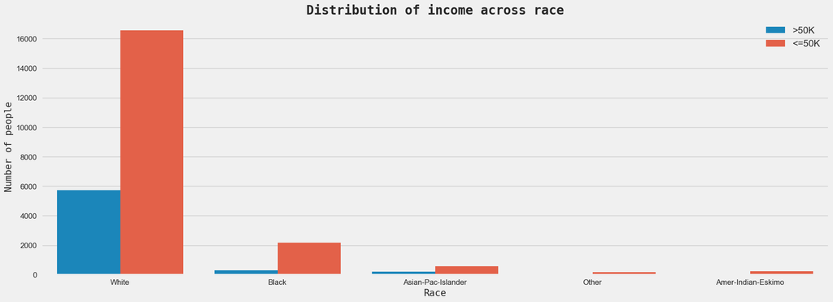

```python
# Creating a countplot of income across race
plt.style.use('fivethirtyeight')
plt.figure(figsize=(20, 7))
sns.countplot(train['race'], hue=train['income'])

plt.title('Distribution of income across race', fontdict={
          'fontname': 'Monospace', 'fontsize': 20, 'fontweight': 'bold'})
plt.xlabel('Race', fontdict={
           'fontname': 'Monospace', 'fontsize': 15})
plt.ylabel('Number of people', fontdict={
           'fontname': 'Monospace', 'fontsize': 15})

plt.tick_params(labelsize=12)
plt.legend(loc=1, prop={'size': 15})
plt.show()
```

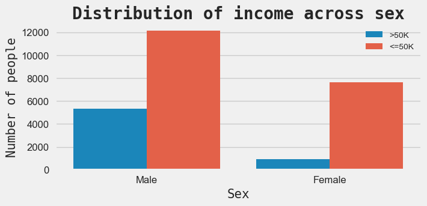

```python
# Creating a countplot of income across sex
plt.style.use('fivethirtyeight')
plt.figure(figsize=(7, 3))
sns.countplot(train['sex'], hue=train['income'])

plt.title('Distribution of income across sex', fontdict={
          'fontname': 'Monospace', 'fontsize': 20, 'fontweight': 'bold'})
plt.xlabel('Sex', fontdict={
           'fontname': 'Monospace', 'fontsize': 15})
plt.ylabel('Number of people', fontdict={
           'fontname': 'Monospace', 'fontsize': 15})

plt.tick_params(labelsize=12)
plt.legend(loc=1, prop={'size': 10})
plt.savefig('bi3.png')
plt.show()
```

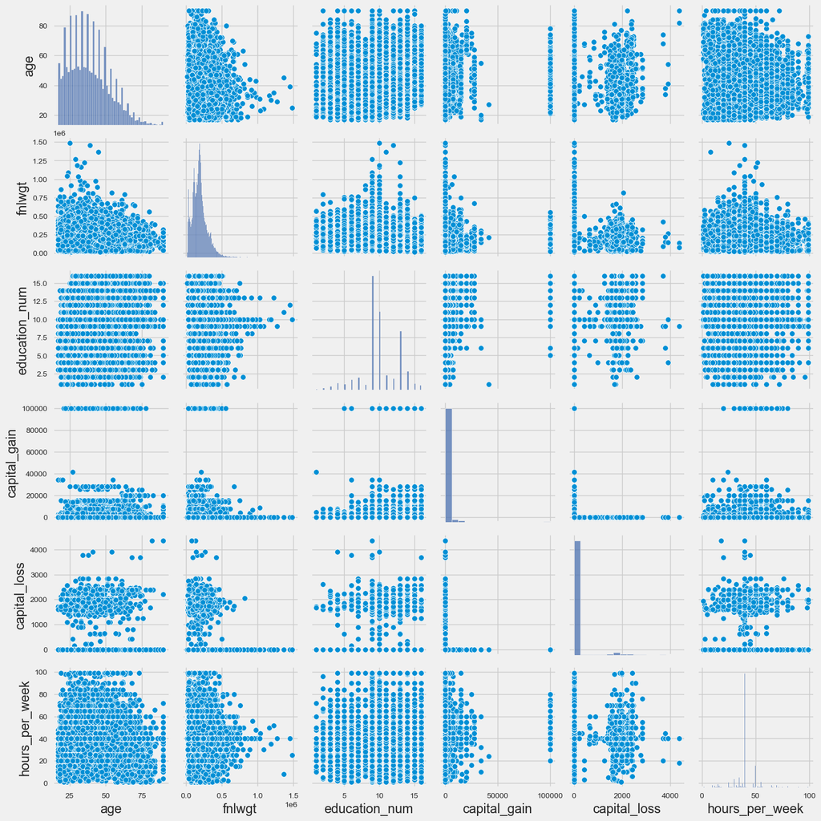

```python
# Creating a pairplot of dataset
sns.pairplot(train)
plt.savefig('multi1.png')
plt.show()
```

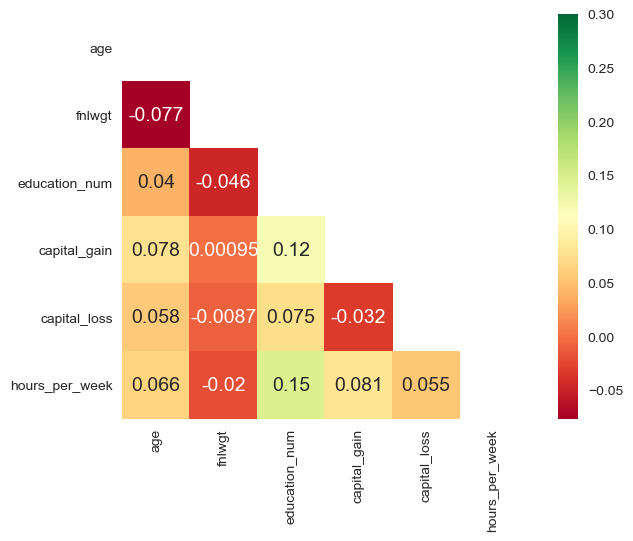

```python
corr = train.corr()
mask = np.zeros_like(corr)
mask[np.triu_indices_from(mask)] = True
with sns.axes_style("white"):
    f, ax = plt.subplots(figsize=(7, 5))
    ax = sns.heatmap(corr, mask=mask, vmax=.3, square=True,
                     annot=True, cmap='RdYlGn')
plt.savefig('multi2.png')
plt.show()
```

### 03. 모델링 - pycaret를 활용

목차로 이동하기

### PyCaret은 무엇일까?

- PyCaret은 Python의 오픈 소스 로우 코드 머신러닝 라이브러리로, ML 실험에서 가설을 인사이트주기 시간으로 줄이는 것을 목표로합니다.
- 이를 통해 데이터 과학자는 종단 간 실험을 빠르고 효율적으로 수행 할 수 있습니다.
- 다른 오픈 소스 기계 학습 라이브러리와 비교하여 PyCaret은 코드 몇 줄만으로 복잡한 기계 학습 작업을 수행하는 데 사용할 수 있는 대체 로우 코드 라이브러리입니다.
- PyCaret은 간단하고 사용하기 쉽습니다.
- PyCaret에서 수행되는 모든 작업 은 배포를 위해 완전히 조정 된 사용자 지정 파이프 라인 에 자동으로 저장됩니다.
- PyCaret은 본질적으로 scikit-learn, XGBoost, LightGBM, spaCy 등과 같은 여러 기계 학습 라이브러리 및 프레임 워크를 둘러싼 Python 래퍼입니다.
- https://pycaret.org/

### 설치 및 작업 순서

- pip install pycaret

### 순서

- 01 setup module를 사용하여 setup
- 02 데이터를 지정하고 preprocessing을 적용.(setup)
- 03 필요시 모델 추가. 모델 확인 후, 커스텀 모델을 추가하거나 모델 튜닝 - add_metric, create_models
- 04 모델 학습 및 비교. compare_models()
- 05 실험 로그를 찍고, 여러가지로 확인

```python
import pycaret

print(pycaret.__version__)
```

```
2.3.10
```

```python
# pycaret 초기화
from pycaret.classification import *

clf = setup(data=train,
            target='income',
            session_id=999,
            high_cardinality_features=['native_country'],
            use_gpu=False,
            silent=True,
            fix_imbalance=False,
            normalize=True,
            feature_selection=False)
```

|  | Description | Value |
| --- | --- | --- |
| 0 | session_id | 999 |
| 1 | Target | income |
| 2 | Target Type | Binary |
| 3 | Label Encoded | <=50K: 0, >50K: 1 |
| 4 | Original Data | (26049, 15) |
| 5 | Missing Values | False |
| 6 | Numeric Features | 5 |
| 7 | Categorical Features | 9 |
| 8 | Ordinal Features | False |
| 9 | High Cardinality Features | True |
| 10 | High Cardinality Method | frequency |
| 11 | Transformed Train Set | (18234, 64) |
| 12 | Transformed Test Set | (7815, 64) |
| 13 | Shuffle Train-Test | True |
| 14 | Stratify Train-Test | False |
| 15 | Fold Generator | StratifiedKFold |
| 16 | Fold Number | 10 |
| 17 | CPU Jobs | -1 |
| 18 | Use GPU | False |
| 19 | Log Experiment | False |
| 20 | Experiment Name | clf-default-name |
| 21 | USI | 2901 |
| 22 | Imputation Type | simple |
| 23 | Iterative Imputation Iteration | None |
| 24 | Numeric Imputer | mean |
| 25 | Iterative Imputation Numeric Model | None |
| 26 | Categorical Imputer | constant |
| 27 | Iterative Imputation Categorical Model | None |
| 28 | Unknown Categoricals Handling | least_frequent |
| 29 | Normalize | True |
| 30 | Normalize Method | zscore |
| 31 | Transformation | False |
| 32 | Transformation Method | None |
| 33 | PCA | False |
| 34 | PCA Method | None |
| 35 | PCA Components | None |
| 36 | Ignore Low Variance | False |
| 37 | Combine Rare Levels | False |
| 38 | Rare Level Threshold | None |
| 39 | Numeric Binning | False |
| 40 | Remove Outliers | False |
| 41 | Outliers Threshold | None |
| 42 | Remove Multicollinearity | False |
| 43 | Multicollinearity Threshold | None |
| 44 | Remove Perfect Collinearity | True |
| 45 | Clustering | False |
| 46 | Clustering Iteration | None |
| 47 | Polynomial Features | False |
| 48 | Polynomial Degree | None |
| 49 | Trignometry Features | False |
| 50 | Polynomial Threshold | None |
| 51 | Group Features | False |
| 52 | Feature Selection | False |
| 53 | Feature Selection Method | classic |
| 54 | Features Selection Threshold | None |
| 55 | Feature Interaction | False |
| 56 | Feature Ratio | False |
| 57 | Interaction Threshold | None |
| 58 | Fix Imbalance | False |
| 59 | Fix Imbalance Method | SMOTE |

```python
# compare_models 함수로 15개의 기본 모델을 학습하고 성능 비교 가능
best_5 = compare_models(n_select=5, sort='F1')
best_5
```

|  | Model | Accuracy | AUC | Recall | Prec. | F1 | Kappa | MCC | TT (Sec) |
| --- | --- | --- | --- | --- | --- | --- | --- | --- | --- |
| catboost | CatBoost Classifier | 0.8727 | 0.9259 | 0.6495 | 0.7839 | 0.7102 | 0.6296 | 0.6343 | 3.9980 |
| lightgbm | Light Gradient Boosting Machine | 0.8705 | 0.9243 | 0.6500 | 0.7750 | 0.7069 | 0.6246 | 0.6287 | 0.2450 |
| xgboost | Extreme Gradient Boosting | 0.8674 | 0.9218 | 0.6468 | 0.7653 | 0.7010 | 0.6166 | 0.6202 | 5.9620 |
| ada | Ada Boost Classifier | 0.8597 | 0.9138 | 0.6165 | 0.7553 | 0.6787 | 0.5902 | 0.5952 | 0.5140 |
| gbc | Gradient Boosting Classifier | 0.8631 | 0.9187 | 0.5847 | 0.7912 | 0.6724 | 0.5883 | 0.5991 | 1.7380 |
| rf | Random Forest Classifier | 0.8547 | 0.9031 | 0.6153 | 0.7368 | 0.6705 | 0.5782 | 0.5822 | 1.3770 |
| lr | Logistic Regression | 0.8524 | 0.9062 | 0.5991 | 0.7373 | 0.6610 | 0.5679 | 0.5730 | 0.7980 |
| svm | SVM - Linear Kernel | 0.8483 | 0.0000 | 0.5624 | 0.7450 | 0.6398 | 0.5463 | 0.5556 | 0.1080 |
| et | Extra Trees Classifier | 0.8323 | 0.8788 | 0.6014 | 0.6681 | 0.6329 | 0.5246 | 0.5259 | 1.7020 |
| lda | Linear Discriminant Analysis | 0.8406 | 0.8926 | 0.5649 | 0.7125 | 0.6300 | 0.5302 | 0.5361 | 0.1720 |
| knn | K Neighbors Classifier | 0.8310 | 0.8539 | 0.5900 | 0.6683 | 0.6265 | 0.5179 | 0.5197 | 2.5570 |
| dt | Decision Tree Classifier | 0.8130 | 0.7469 | 0.6194 | 0.6096 | 0.6143 | 0.4910 | 0.4911 | 0.1150 |
| ridge | Ridge Classifier | 0.8395 | 0.0000 | 0.5063 | 0.7442 | 0.6025 | 0.5065 | 0.5213 | 0.0380 |
| nb | Naive Bayes | 0.5641 | 0.8128 | 0.9491 | 0.3501 | 0.5115 | 0.2470 | 0.3511 | 0.0380 |
| qda | Quadratic Discriminant Analysis | 0.4942 | 0.5509 | 0.6602 | 0.2738 | 0.3853 | 0.0699 | 0.0895 | 0.1180 |
| dummy | Dummy Classifier | 0.7596 | 0.5000 | 0.0000 | 0.0000 | 0.0000 | 0.0000 | 0.0000 | 0.0280 |

```
[<catboost.core.CatBoostClassifier at 0x7f8c5280b370>,
 LGBMClassifier(boosting_type='gbdt', class_weight=None, colsample_bytree=1.0,
                importance_type='split', learning_rate=0.1, max_depth=-1,
                min_child_samples=20, min_child_weight=0.001, min_split_gain=0.0,
                n_estimators=100, n_jobs=-1, num_leaves=31, objective=None,
                random_state=999, reg_alpha=0.0, reg_lambda=0.0, silent=True,
                subsample=1.0, subsample_for_bin=200000, subsample_freq=0),
 XGBClassifier(base_score=0.5, booster='gbtree', callbacks=None,
               colsample_bylevel=1, colsample_bynode=1, colsample_bytree=1,
               early_stopping_rounds=None, enable_categorical=False,
               eval_metric=None, gamma=0, gpu_id=-1, grow_policy='depthwise',
               importance_type=None, interaction_constraints='',
               learning_rate=0.300000012, max_bin=256, max_cat_to_onehot=4,
               max_delta_step=0, max_depth=6, max_leaves=0, min_child_weight=1,
               missing=nan, monotone_constraints='()', n_estimators=100,
               n_jobs=-1, num_parallel_tree=1, objective='binary:logistic',
               predictor='auto', random_state=999, reg_alpha=0, ...),
 AdaBoostClassifier(algorithm='SAMME.R', base_estimator=None, learning_rate=1.0,
                    n_estimators=50, random_state=999),
 GradientBoostingClassifier(ccp_alpha=0.0, criterion='friedman_mse', init=None,
                            learning_rate=0.1, loss='deviance', max_depth=3,
                            max_features=None, max_leaf_nodes=None,
                            min_impurity_decrease=0.0, min_impurity_split=None,
                            min_samples_leaf=1, min_samples_split=2,
                            min_weight_fraction_leaf=0.0, n_estimators=100,
                            n_iter_no_change=None, presort='deprecated',
                            random_state=999, subsample=1.0, tol=0.0001,
                            validation_fraction=0.1, verbose=0,
                            warm_start=False)]
```

### 사용 가능한 모델

- https://pycaret.gitbook.io/docs/

```python
# 지정 모델에서 성능 좋은 5가지 모델을 추출
best_5 = compare_models(n_select=5,
            include=['lightgbm', 'xgboost', 'gbc', 'rf', 'ada', 'catboost', 'et'])
```

|  | Model | Accuracy | AUC | Recall | Prec. | F1 | Kappa | MCC | TT (Sec) |
| --- | --- | --- | --- | --- | --- | --- | --- | --- | --- |
| catboost | CatBoost Classifier | 0.8727 | 0.9259 | 0.6495 | 0.7839 | 0.7102 | 0.6296 | 0.6343 | 3.6070 |
| lightgbm | Light Gradient Boosting Machine | 0.8705 | 0.9243 | 0.6500 | 0.7750 | 0.7069 | 0.6246 | 0.6287 | 0.2720 |
| xgboost | Extreme Gradient Boosting | 0.8674 | 0.9218 | 0.6468 | 0.7653 | 0.7010 | 0.6166 | 0.6202 | 6.6840 |
| gbc | Gradient Boosting Classifier | 0.8631 | 0.9187 | 0.5847 | 0.7912 | 0.6724 | 0.5883 | 0.5991 | 1.8350 |
| ada | Ada Boost Classifier | 0.8597 | 0.9138 | 0.6165 | 0.7553 | 0.6787 | 0.5902 | 0.5952 | 0.5630 |
| rf | Random Forest Classifier | 0.8547 | 0.9031 | 0.6153 | 0.7368 | 0.6705 | 0.5782 | 0.5822 | 1.5600 |
| et | Extra Trees Classifier | 0.8323 | 0.8788 | 0.6014 | 0.6681 | 0.6329 | 0.5246 | 0.5259 | 1.8330 |

```python
### 5개의 모델을 앙상블하여 성능 개선
blended = blend_models(estimator_list=best_5, fold=5, method='auto')
```

| Fold | Accuracy | AUC | Recall | Prec. | F1 | Kappa | MCC |
| --- | --- | --- | --- | --- | --- | --- | --- |
| 0 | 0.8783 | 0.9289 | 0.6587 | 0.7992 | 0.7222 | 0.6451 | 0.6501 |
| 1 | 0.8711 | 0.9256 | 0.6431 | 0.7822 | 0.7059 | 0.6244 | 0.6293 |
| 2 | 0.8634 | 0.9214 | 0.6135 | 0.7719 | 0.6836 | 0.5980 | 0.6044 |
| 3 | 0.8684 | 0.9269 | 0.6271 | 0.7824 | 0.6962 | 0.6135 | 0.6196 |
| 4 | 0.8697 | 0.9232 | 0.6279 | 0.7868 | 0.6984 | 0.6167 | 0.6231 |
| Mean | 0.8702 | 0.9252 | 0.6340 | 0.7845 | 0.7013 | 0.6195 | 0.6253 |
| Std | 0.0048 | 0.0027 | 0.0155 | 0.0088 | 0.0127 | 0.0154 | 0.0149 |

```python
blended
```

```
VotingClassifier(estimators=[('catboost',
                              <catboost.core.CatBoostClassifier object at 0x7f8c3743e070>),
                             ('lightgbm',
                              LGBMClassifier(boosting_type='gbdt',
                                             class_weight=None,
                                             colsample_bytree=1.0,
                                             importance_type='split',
                                             learning_rate=0.1, max_depth=-1,
                                             min_child_samples=20,
                                             min_child_weight=0.001,
                                             min_split_gain=0.0,
                                             n_estimators=100, n_jobs=-1,
                                             num_leaves=31, objec...
                                                         min_weight_fraction_leaf=0.0,
                                                         n_estimators=100,
                                                         n_iter_no_change=None,
                                                         presort='deprecated',
                                                         random_state=999,
                                                         subsample=1.0,
                                                         tol=0.0001,
                                                         validation_fraction=0.1,
                                                         verbose=0,
                                                         warm_start=False)),
                             ('ada',
                              AdaBoostClassifier(algorithm='SAMME.R',
                                                 base_estimator=None,
                                                 learning_rate=1.0,
                                                 n_estimators=50,
                                                 random_state=999))],
                 flatten_transform=True, n_jobs=-1, verbose=False,
                 voting='soft', weights=None)
```

```python
# 앞서 kfold로 훈련했을때 가장 best였던 parameter를 기준으로
# train data를 전체 다사용해서 최종 학습
final = finalize_model(blended)
final
```

```
VotingClassifier(estimators=[('catboost',
                              <catboost.core.CatBoostClassifier object at 0x7f8c52815f40>),
                             ('lightgbm',
                              LGBMClassifier(boosting_type='gbdt',
                                             class_weight=None,
                                             colsample_bytree=1.0,
                                             importance_type='split',
                                             learning_rate=0.1, max_depth=-1,
                                             min_child_samples=20,
                                             min_child_weight=0.001,
                                             min_split_gain=0.0,
                                             n_estimators=100, n_jobs=-1,
                                             num_leaves=31, objec...
                                                         min_weight_fraction_leaf=0.0,
                                                         n_estimators=100,
                                                         n_iter_no_change=None,
                                                         presort='deprecated',
                                                         random_state=999,
                                                         subsample=1.0,
                                                         tol=0.0001,
                                                         validation_fraction=0.1,
                                                         verbose=0,
                                                         warm_start=False)),
                             ('ada',
                              AdaBoostClassifier(algorithm='SAMME.R',
                                                 base_estimator=None,
                                                 learning_rate=1.0,
                                                 n_estimators=50,
                                                 random_state=999))],
                 flatten_transform=True, n_jobs=-1, verbose=False,
                 voting='soft', weights=None)
```

```python
test.columns
```

```
Index(['age', 'workclass', 'fnlwgt', 'education', 'education_num',
       'marital_status', 'occupation', 'relationship', 'race', 'sex',
       'capital_gain', 'capital_loss', 'hours_per_week', 'native_country'],
      dtype='object')
```

```python
test.head()
```

| id | age | workclass | fnlwgt | education | education_num | marital_status | occupation | relationship | race | sex | capital_gain | capital_loss | hours_per_week | native_country |
| --- | --- | --- | --- | --- | --- | --- | --- | --- | --- | --- | --- | --- | --- | --- |
| 0 | 28 | Private | 67661 | Some-college | 10 | Never-married | Adm-clerical | Other-relative | White | Female | 0 | 0 | 40 | United-States |
| 1 | 40 | Self-emp-inc | 37869 | HS-grad | 9 | Married-civ-spouse | Exec-managerial | Husband | White | Male | 0 | 0 | 50 | United-States |
| 2 | 20 | Private | 109952 | Some-college | 10 | Never-married | Handlers-cleaners | Own-child | White | Male | 0 | 0 | 25 | United-States |
| 3 | 40 | Private | 114537 | Assoc-voc | 11 | Married-civ-spouse | Exec-managerial | Husband | White | Male | 0 | 0 | 50 | United-States |
| 4 | 37 | Private | 51264 | Doctorate | 16 | Married-civ-spouse | Prof-specialty | Husband | White | Male | 0 | 0 | 99 | France |

```python
# test set에 대해서 모델 평가
# Label라는 컬럼이 생기고, 여기
prediction_test = predict_model(final, data=test)
prediction_test
```

| id | age | workclass | fnlwgt | education | education_num | marital_status | occupation | relationship | race | sex | capital_gain | capital_loss | hours_per_week | native_country | Label | Score |
| --- | --- | --- | --- | --- | --- | --- | --- | --- | --- | --- | --- | --- | --- | --- | --- | --- |
| 0 | 28 | Private | 67661 | Some-college | 10 | Never-married | Adm-clerical | Other-relative | White | Female | 0 | 0 | 40 | United-States | <=50K | 0.8980 |
| 1 | 40 | Self-emp-inc | 37869 | HS-grad | 9 | Married-civ-spouse | Exec-managerial | Husband | White | Male | 0 | 0 | 50 | United-States | >50K | 0.5189 |
| 2 | 20 | Private | 109952 | Some-college | 10 | Never-married | Handlers-cleaners | Own-child | White | Male | 0 | 0 | 25 | United-States | <=50K | 0.9088 |
| 3 | 40 | Private | 114537 | Assoc-voc | 11 | Married-civ-spouse | Exec-managerial | Husband | White | Male | 0 | 0 | 50 | United-States | >50K | 0.6446 |
| 4 | 37 | Private | 51264 | Doctorate | 16 | Married-civ-spouse | Prof-specialty | Husband | White | Male | 0 | 0 | 99 | France | <=50K | 0.5418 |
| ... | ... | ... | ... | ... | ... | ... | ... | ... | ... | ... | ... | ... | ... | ... | ... | ... |
| 6507 | 35 | Private | 61343 | Bachelors | 13 | Married-civ-spouse | Sales | Husband | White | Male | 0 | 0 | 40 | United-States | <=50K | 0.5037 |
| 6508 | 41 | Self-emp-inc | 32185 | Bachelors | 13 | Married-civ-spouse | Tech-support | Husband | White | Male | 0 | 0 | 40 | United-States | >50K | 0.5528 |
| 6509 | 39 | Private | 409189 | 5th-6th | 3 | Married-civ-spouse | Other-service | Husband | White | Male | 0 | 0 | 40 | Mexico | <=50K | 0.8574 |
| 6510 | 35 | Private | 180342 | HS-grad | 9 | Married-civ-spouse | Craft-repair | Husband | White | Male | 0 | 0 | 40 | United-States | <=50K | 0.7286 |
| 6511 | 28 | Private | 156819 | HS-grad | 9 | Divorced | Handlers-cleaners | Unmarried | White | Female | 0 | 0 | 36 | United-States | <=50K | 0.8974 |

6512 rows × 16 columns

```python
prediction_test.loc[ prediction_test['Label'] == "<=50K", "pred" ] = 0
prediction_test.loc[ prediction_test['Label'] == ">50K", "pred" ] = 1
prediction_test['pred'] = prediction_test['pred'].astype(int)
prediction_test['pred']
```

```
id
0       0
1       1
2       0
3       1
4       0
       ..
6507    0
6508    1
6509    0
6510    0
6511    0
Name: pred, Length: 6512, dtype: int64
```

```python
submission = pd.read_csv(os.path.join(dirname, 'sample_submission.csv'))
display(submission.head(5))
submission['prediction'] = prediction_test['pred']
submission
```

|  | id | prediction |
| --- | --- | --- |
| 0 | 0 | 0 |
| 1 | 1 | 0 |
| 2 | 2 | 0 |
| 3 | 3 | 0 |
| 4 | 4 | 0 |

|  | id | prediction |
| --- | --- | --- |
| 0 | 0 | 0 |
| 1 | 1 | 1 |
| 2 | 2 | 0 |
| 3 | 3 | 1 |
| 4 | 4 | 0 |
| ... | ... | ... |
| 6507 | 6507 | 0 |
| 6508 | 6508 | 1 |
| 6509 | 6509 | 0 |
| 6510 | 6510 | 0 |
| 6511 | 6511 | 0 |

6512 rows × 2 columns

```python
submission.to_csv('submission_5th_pycaret.csv', index=False)
```

- 실제 모델과 달리 평가 데이터가 공개되어 있음(Data Leakage). 이에 따라 평가가 가능.
- 모델링의 중요 지표의 일반화를 내려놓고, test데이터에 대한 overfitting하는 과정을 갖는다.
- Score: 0.87482

### CatBoost 모델링

- Pycaret는 좋은 모델링 도구이지만 미세한 파라미터 조정이 어려운 부분이 있음.
- pycaret에서 가장 좋은 수치를 가진 catboost를 직접 호출하여 파라미터 조정을 거친다.(submission 제출)

```python
raw_train = train.copy()
raw_test = test.copy()
```

```python
from catboost import CatBoostClassifier
import catboost
print(catboost.__version__)
```

```
1.0.4
```

```python
def preprocess(df):
    # null값이 count 출력
    print(df.apply(lambda x: sum(x.isnull()), axis=0))
    print(' ')

    # income column을 string에서 integer로 변경
    df['income_level'] = np.where(df.income == '<=50K', 0, 1)

    # 성별
    df['gender'] = df['sex'].map({'Male': 0, 'Female': 1}).astype(int)


    # 인종
    ethnicity_key = {'White': 0, 'Black': 1, 'Asian-Pac-Islander': 2,
                     'Amer-Indian-Eskimo': 3, 'Other': 4}

    df['ethnicity'] = df['race'].map(ethnicity_key).astype(int)

    # 국가
    origin_key = {'?': 0, 'United-States': 1, 'Mexico': 2, 'Philippines': 3,
                  'Germany': 4, 'Canada': 5, 'Puerto-Rico': 6, 'El-Salvador': 7,
                  'India': 8, 'Cuba': 9, 'England': 10, 'Jamaica': 11, 'South': 12,
                  'China': 13, 'Italy': 14, 'Dominican-Republic': 15, 'Vietnam': 16,
                  'Guatemala': 17, 'Japan': 18, 'Poland': 19, 'Columbia': 20, 'Taiwan': 21,
                  'Haiti': 22, 'Iran': 23, 'Portugal': 24, 'Nicaragua': 25, 'Peru': 26,
                  'France': 27, 'Greece': 28, 'Ecuador': 29, 'Ireland': 30, 'Hong': 31,
                  'Trinadad&Tobago': 32, 'Cambodia': 33, 'Laos': 34, 'Thailand': 35,
                  'Yugoslavia': 36, 'Outlying-US(Guam-USVI-etc)': 37, 'Hungary': 38,
                  'Honduras': 39, 'Scotland': 40, 'Holand-Netherlands': 41}

    df['native_country'] = df['native_country'].map(origin_key).astype(int)

    # 고용형태
    work_key = {'Private': 0, 'Self-emp-not-inc': 1, 'Local-gov': 2, '?': 3,
                'State-gov': 4, 'Self-emp-inc': 5, 'Federal-gov': 6,
                'Without-pay': 7, 'Never-worked': 8}

    df['work'] = df['workclass'].map(work_key).astype(int)

    # 결혼상태
    marital_status_key = {'Married-civ-spouse': 0, 'Never-married': 1, 'Divorced': 2,
                          'Separated': 3, 'Widowed': 4, 'Married-spouse-absent': 5,
                          'Married-AF-spouse': 6}

    df['marital_status'] = df['marital_status'].map(marital_status_key).astype(int)

    # 업종
    occupation_key = {'Prof-specialty': 0, 'Craft-repair': 1, 'Exec-managerial': 2,
                      'Adm-clerical': 3, 'Sales': 4, 'Other-service': 5,
                      'Machine-op-inspct': 6, '?': 7, 'Transport-moving': 8,
                      'Handlers-cleaners': 9, 'Farming-fishing': 10, 'Tech-support': 11,
                      'Protective-serv': 12, 'Priv-house-serv': 13, 'Armed-Forces': 14}

    df['occupation'] = df['occupation'].map(occupation_key).astype(int)

    # 가족관계
    relationship_key = {'Husband': 0, 'Not-in-family': 1, 'Own-child': 2, 'Unmarried': 3,
                        'Wife': 4, 'Other-relative': 5}

    df['relationship'] = df['relationship'].map(relationship_key).astype(int)

    # raw column 삭제
    df = df.drop(['income'], axis=1)
    df = df.drop(['sex'], axis=1)
    df = df.drop(['race'], axis=1)
    # df = df.drop(['native.country'], axis=1)
    df = df.drop(['workclass'], axis=1)
    # df = df.drop(['marital.status'], axis=1)
    df = df.drop(['education'], axis=1)
    # dummy = pd.get_dummies(df['education'], prefix='education')
    # del df['education']
    # df = pd.concat([df, dummy], axis=1)
    # df = df.drop(['education_num'], axis=1)

    # 주당 근무 시간
    df['hours_per_week'] = df['hours_per_week'].astype(int)
    # df.loc[df['hours_per_week'] < 40, 'hours_per_week'] = 0
    # df.loc[df['hours_per_week'] == 40, 'hours_per_week'] = 1
    # df.loc[df['hours_per_week'] > 40, 'hours_per_week'] = 2

    # 양도소득차
    df['capital_diff'] = df['capital_gain'] - df['capital_loss']
    #df['fnlwgt_log'] = np.log(df['fnlwgt'])
    #df['education_num'] /= 10
    # df['age_log'] = np.log(df['age'])
    #del df['fnlwgt']
    # del df['native_country']

    return df
```

```python
# 데이터 전처리
all_data = pd.concat([raw_train, raw_test])
all_data = preprocess(all_data)
train = all_data.iloc[:len(raw_train)]
test = all_data.iloc[len(raw_train):]

train_x = train.drop(['income_level'], axis=1)
train_y = train['income_level']

test_x = test.drop(['income_level'], axis=1)
```

```
age                  0
workclass            0
fnlwgt               0
education            0
education_num        0
marital_status       0
occupation           0
relationship         0
race                 0
sex                  0
capital_gain         0
capital_loss         0
hours_per_week       0
native_country       0
income            6512
dtype: int64
```

```python
prediction = np.zeros(len(test_x))
learning_params = [
    {
    "learning_rate": 0.2,
    "iterations": 212,
    "depth": 4,
    "l2_leaf_reg": 3,
    "random_seed": 62,
    "random_strength": 1,
    "eval_metric": 'Accuracy'
    },
    {
    "learning_rate": 0.2,
    "iterations": 273,
    "depth": 4,
    "l2_leaf_reg": 3,
    "random_seed": 8,
    "random_strength": 1,
    "eval_metric": 'Accuracy'
    },
    {
    "learning_rate": 0.2,
    "iterations": 277,
    "depth": 4,
    "l2_leaf_reg": 3,
    "random_seed": 145,
    "random_strength": 1,
    "eval_metric": 'Accuracy'
    }]

for param in learning_params:
    model = CatBoostClassifier(**param)
    model.fit(train_x, train_y, verbose=False)
    prediction += model.predict(test_x)

prediction = prediction / 3
prediction[prediction < 1] = 0
prediction = prediction.astype(np.int64)
```

```python
from sklearn.metrics import accuracy_score
```

```python
# 학습셋의 성능
train_prediction = model.predict(train_x)
accuracy_score(train_y, train_prediction)
```

```
0.8893623555606741
```

```python
# 예측 점수가 낮은 결과들의 정확도
train_score_list = model.predict_proba(train_x)
low_score_indexes = np.where(np.logical_and(train_score_list[:,0] < 0.55,
                                            train_score_list[:,0] > 0.45))[0]
accuracy_score(train_y[low_score_indexes], train_prediction[low_score_indexes])
```

```
0.5264116575591985
```

```python
score_list = model.predict_proba(test_x)
```

- model의 예측치를 0.55 ~ 0.50, 0.45 ~ 0.50 2분류로 나눠서 임의로 지정하고 submission 제출을 통해서 best random값을 찾는다.

```python
score_ranges = [
    (0.55, 0.50, 999, 30), # label 1 min
    (0.50, 0.45, 2000000, 9)  # label 0
]
for up, down, seed, random_range in score_ranges:
    indexes = np.where(np.logical_and(score_list[:,0] < up, score_list[:,0] > down))[0]
    np.random.seed(seed)
    rand_val = np.random.randint(0,random_range,size=len(indexes))
    rand_threshold = np.random.randint(1, random_range -1)
    rand_val[rand_val<rand_threshold] = 0;
    rand_val[rand_val>=rand_threshold] = 1
    prediction[indexes] = rand_val
```

### 제출

```python
submission = pd.read_csv(os.path.join(dirname, 'sample_submission.csv'))
submission['prediction'] = prediction
submission.to_csv('submission_6th_catBoost.csv', index=False)
```

- REF
  - https://velog.io/@jee-9/PyCaret-Tutorial-Docs%EC%99%80-%ED%95%A8%EA%BB%98-%EA%B0%84%EB%8B%A8%ED%95%98%EA%B2%8C-%EC%9D%B4%EC%9A%A9%ED%95%B4%EB%B3%B4%EA%B8%B0
- Score: 0.87040